# Tarea DAPC

Vero

2025-04-10

# Cargar libreria

adegenet permite usar datos microbov

```r
library(vcfR)
library(adegenet)
data(microbov)
```

# 1.- Correr este ejemplo paso por paso y explorar el objeto que sale del dapc.

tab<-summary(dapc(microbov, n.da=100, n.pca=3))$assign.per.pop*100

La linea de codigo involucra 3 instrucciones, primero hacer un dapc, seguido de un resumen de ese dapc y tercero el calculo del porcentaje de la proporcion de reasignacion exitosa a cada poblacion

## Crear dapc con la base el objeto microbov.

```r
dapc(microbov, n.da=100, n.pca=3)
```

```
##  #################################################
##  # Discriminant Analysis of Principal Components #
##  #################################################
## class: dapc
## $call: dapc.genind(x = microbov, n.pca = 3, n.da = 100)
##
## $n.pca: 3 first PCs of PCA used
## $n.da: 3 discriminant functions saved
## $var (proportion of conserved variance): 0.175
##
## $eig (eigenvalues): 586.9 234.3 104  vector    length content
## 1 $eig      3      eigenvalues
## 2 $grp      704    prior group assignment
## 3 $prior    15     prior group probabilities
## 4 $assign   704    posterior group assignment
## 5 $pca.cent 373    centring vector of PCA
## 6 $pca.norm 373    scaling vector of PCA
## 7 $pca.eig  341    eigenvalues of PCA
##
##   data.frame    nrow ncol content
## 1 $tab          704  3    retained PCs of PCA
## 2 $means        15   3    group means
## 3 $loadings     3    3    loadings of variables
## 4 $ind.coord    704  3    coordinates of individuals (principal components)
## 5 $grp.coord    15   3    coordinates of groups
## 6 $posterior    704  15   posterior membership probabilities
## 7 $pca.loadings 373  3    PCA loadings of original variables
## 8 $var.contr    373  3    contribution of original variables
```

```r
choco<- dapc(microbov, n.da=100, n.pca=3)

choco
```

```
##  #################################################
##  # Discriminant Analysis of Principal Components #
##  #################################################
## class: dapc
## $call: dapc.genind(x = microbov, n.pca = 3, n.da = 100)
##
## $n.pca: 3 first PCs of PCA used
## $n.da: 3 discriminant functions saved
## $var (proportion of conserved variance): 0.175
##
## $eig (eigenvalues): 586.9 234.3 104  vector    length content
## 1 $eig      3      eigenvalues
## 2 $grp      704    prior group assignment
## 3 $prior    15     prior group probabilities
## 4 $assign   704    posterior group assignment
## 5 $pca.cent 373    centring vector of PCA
## 6 $pca.norm 373    scaling vector of PCA
## 7 $pca.eig  341    eigenvalues of PCA
##
##   data.frame    nrow ncol content
## 1 $tab          704  3    retained PCs of PCA
## 2 $means        15   3    group means
## 3 $loadings     3    3    loadings of variables
## 4 $ind.coord    704  3    coordinates of individuals (principal components)
## 5 $grp.coord    15   3    coordinates of groups
## 6 $posterior    704  15   posterior membership probabilities
## 7 $pca.loadings 373  3    PCA loadings of original variables
## 8 $var.contr    373  3    contribution of original variables
```

```r
choco$assign
```

```
##   [1] Zebu            Zebu            Somba           Borgou
##   [5] Borgou          Somba           Somba           Somba
##   [9] Somba           Borgou          Borgou          Borgou
##  [13] Borgou          Borgou          Borgou          Borgou
##  [17] Borgou          Borgou          Borgou          Borgou
##  [21] Borgou          Borgou          Borgou          Borgou
##  [25] Borgou          Borgou          Borgou          Borgou
##  [29] Borgou          Borgou          Borgou          Borgou
##  [33] Borgou          Borgou          Borgou          Borgou
##  [37] Borgou          Borgou          Somba           Borgou
##  [41] Borgou          Zebu            Borgou          Zebu
##  [45] Borgou          Borgou          Borgou          Zebu
##  [49] Zebu            Borgou          Zebu            Zebu
##  [53] Zebu            Zebu            Zebu            Borgou
##  [57] Zebu            Zebu            Borgou          Zebu
```

[output cut: 162 more lines]

## Resumen de DAPC.

Summary nos proporciona la informacion de dimensiones, poblaciones, proporcion de muestras asignadas a cada poblacion, tamaño de los grupos previos y posterior tamaño de los grupos.

```r
summary(dapc(microbov, n.da=100, n.pca=3))
```

```
## $n.dim
## [1] 3
##
## $n.pop
## [1] 15
##
## $assign.prop
## [1] 0.5411932
##
## $assign.per.pop
##          Borgou            Zebu       Lagunaire           NDama           Somba
##       0.7600000       0.9000000       0.9803922       0.2000000       0.8000000
##          Aubrac        Bazadais BlondeAquitaine    BretPieNoire       Charolais
##       0.3800000       0.8297872       0.2622951       0.0000000       0.6909091
##          Gascon        Limousin      MaineAnjou     Montbeliard          Salers
##       0.2600000       0.0600000       0.8367347       0.1666667       0.5600000
##
## $prior.grp.size
##
##          Borgou            Zebu       Lagunaire           NDama           Somba
##              50              50              51              30              50
##          Aubrac        Bazadais BlondeAquitaine    BretPieNoire       Charolais
##              50              47              61              31              55
##          Gascon        Limousin      MaineAnjou     Montbeliard          Salers
##              50              50              49              30              50
##
## $post.grp.size
##
##          Borgou            Zebu       Lagunaire           NDama           Somba
##              47              51              53              12              68
##          Aubrac        Bazadais BlondeAquitaine    BretPieNoire       Charolais
##              54              52              79               2              81
##          Gascon        Limousin      MaineAnjou     Montbeliard          Salers
##              51              22              53              14              65
```

Eran 50 Borgou pero fallo en 12 o sea que lo hizo bien en 50-12 = 38 osea lo hizo bien en 38/50 o sea 0.76 osea 76%

## Porcentaje de la asignacion a la poblacion.

assign.per.pop*100 Saca el porcentaje de la proporcion de reasignacion exitosa a cada poblacion

```r
summary(dapc(microbov, n.da=100, n.pca=3))$assign.per.pop*100
```

```
##          Borgou            Zebu       Lagunaire           NDama           Somba
##        76.00000        90.00000        98.03922        20.00000        80.00000
##          Aubrac        Bazadais BlondeAquitaine    BretPieNoire       Charolais
##        38.00000        82.97872        26.22951         0.00000        69.09091
##          Gascon        Limousin      MaineAnjou     Montbeliard          Salers
##        26.00000         6.00000        83.67347        16.66667        56.00000
```

# Duda: Como se calcula la asignacion de poblacion: assign.per.pop

The slot assign.per.pop indicates the proportions of successful reassignment (based on the discriminant functions) of individuals to their original clusters. Large values indicate clear-cut clusters, while low values suggest admixed groups.

# 2.- ¿Qué sale en esta gráfica al hacer la clasificación por find.clusters o por categoría de daño?

En el set de muestras de camaras (AE, CC, CA) con todos los SNPs. A partir de find.cluster salen los grupos en los que se dividen los datos por la estructura genetica de los individuos, se obtienen 5 que corresponden con los grupos familiares. La asignacion es contundente roja.

```r
#Crear objeto genlight con datos camaras
vcfR_chambers <- read.vcfR("../../../../VCF/GBSM_Fenotype_AECCCA.recode.vcf")
```

[output not shown]

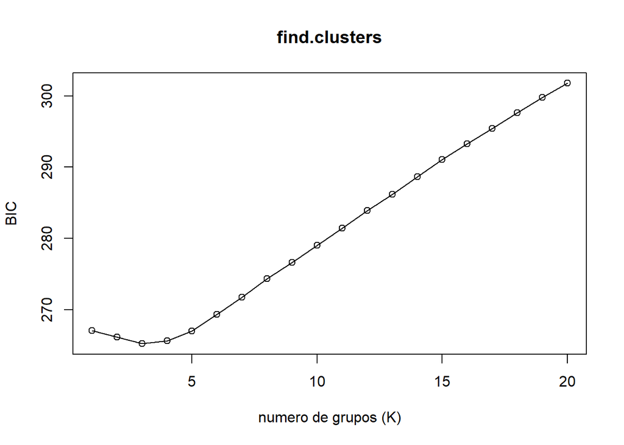

```r
vcf_chambers<-vcfR2genlight(vcfR_chambers)

grp <- find.clusters(vcf_chambers, max.n.clust = 20, n.pca = 50, choose.n.clust = FALSE, stat = "BIC", method = "kmeans")

#find.clusters(vcf_chambers)

plot(grp$Kstat, type = "o", xlab = "numero de grupos (K)", ylab = "BIC", main = "find.clusters")
```

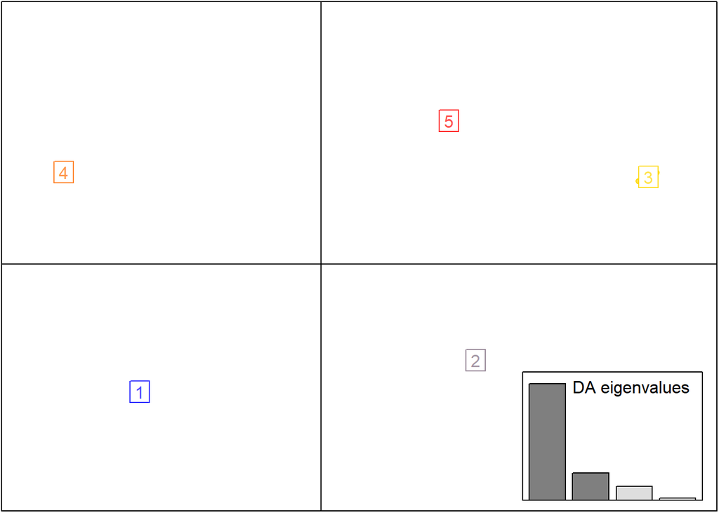

```r
# corremos dapc con los grupos formados
dapcfindcluster <- dapc(vcf_chambers, grp$grp, n.pca = 50, n.da = 3)

scatter(dapcfindcluster)
```

```r
table(grp$grp)
```

```
##
##  1  2  3  4  5
## 11 16  8 15  6
```

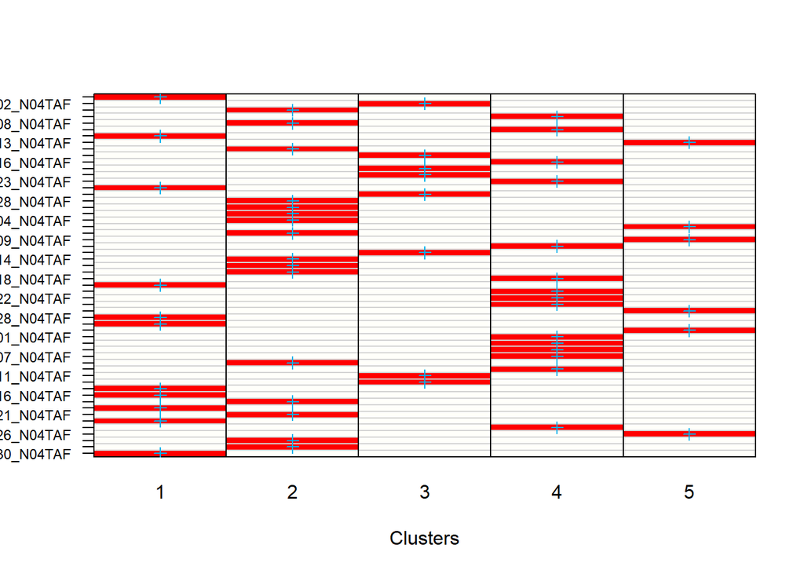

```r
assignplot(dapcfindcluster)
```

```r
summary(dapcfindcluster)
```

```
## $n.dim
## [1] 3
##
## $n.pop
## [1] 5
##
## $assign.prop
## [1] 1
##
## $assign.per.pop
## 1 2 3 4 5
## 1 1 1 1 1
##
## $prior.grp.size
##
##  1  2  3  4  5
## 11 16  8 15  6
##
## $post.grp.size
##
##  1  2  3  4  5
## 11 16  8 15  6
```

```r
# cargamos los datos de las categorias de daño
meta <- read.table("../outputs/pop_Fenotype_AECCCA_DAPC.txt", header=TRUE, sep="\t")  # Si está separado por tabulaciones

pop(vcf_chambers) <- meta$suv_damozo


# corremos dapc con los grupos de asintomatico y sintomatico
dapc_AECCCA <- dapc(vcf_chambers, var.contrib = TRUE, n.pca = 25, n.da = 4)
assignplot(dapc_AECCCA)
```

[output not shown]

```r
dapc_AECCCA$grp
```

```
##  [1] survive_1 survive_1 survive_0 survive_1 survive_0 survive_0 survive_0
##  [8] survive_0 survive_0 survive_0 survive_0 survive_0 survive_0 survive_0
## [15] survive_1 survive_0 survive_0 survive_0 survive_1 survive_1 survive_1
## [22] survive_1 survive_1 survive_1 survive_1 survive_0 survive_0 survive_0
## [29] survive_1 survive_0 survive_0 survive_0 survive_0 survive_0 survive_0
## [36] survive_0 survive_1 survive_0 survive_0 survive_0 survive_0 survive_0
## [43] survive_1 survive_1 survive_0 survive_1 survive_1 survive_1 survive_1
## [50] survive_0 survive_0 survive_0 survive_1 survive_0 survive_1 survive_0
## Levels: survive_0 survive_1
```

```r
summary(dapc_AECCCA)
```

```
## $n.dim
## [1] 1
##
## $n.pop
## [1] 2
##
## $assign.prop
## [1] 0.8035714
##
## $assign.per.pop
## survive_0 survive_1
## 0.8571429 0.7142857
##
## $prior.grp.size
##
## survive_0 survive_1
##        35        21
##
## $post.grp.size
##
## survive_0 survive_1
##        36        20
```

```r
vcf_chambers@pop
```

```
##  [1] survive_1 survive_1 survive_0 survive_1 survive_0 survive_0 survive_0
##  [8] survive_0 survive_0 survive_0 survive_0 survive_0 survive_0 survive_0
## [15] survive_1 survive_0 survive_0 survive_0 survive_1 survive_1 survive_1
## [22] survive_1 survive_1 survive_1 survive_1 survive_0 survive_0 survive_0
## [29] survive_1 survive_0 survive_0 survive_0 survive_0 survive_0 survive_0
## [36] survive_0 survive_1 survive_0 survive_0 survive_0 survive_0 survive_0
## [43] survive_1 survive_1 survive_0 survive_1 survive_1 survive_1 survive_1
## [50] survive_0 survive_0 survive_0 survive_1 survive_0 survive_1 survive_0
## Levels: survive_0 survive_1
```

# Categorizacion real

```r
vcf_chambers@pop
```

```
##  [1] survive_1 survive_1 survive_0 survive_1 survive_0 survive_0 survive_0
##  [8] survive_0 survive_0 survive_0 survive_0 survive_0 survive_0 survive_0
## [15] survive_1 survive_0 survive_0 survive_0 survive_1 survive_1 survive_1
## [22] survive_1 survive_1 survive_1 survive_1 survive_0 survive_0 survive_0
## [29] survive_1 survive_0 survive_0 survive_0 survive_0 survive_0 survive_0
## [36] survive_0 survive_1 survive_0 survive_0 survive_0 survive_0 survive_0
## [43] survive_1 survive_1 survive_0 survive_1 survive_1 survive_1 survive_1
## [50] survive_0 survive_0 survive_0 survive_1 survive_0 survive_1 survive_0
## Levels: survive_0 survive_1
```

# Categorizacion por parametros en el DAPC

```r
dapc_AECCCA$assign
```

```
##  [1] survive_1 survive_1 survive_1 survive_1 survive_0 survive_0 survive_1
##  [8] survive_0 survive_0 survive_0 survive_0 survive_0 survive_0 survive_0
## [15] survive_1 survive_1 survive_1 survive_0 survive_0 survive_0 survive_1
## [22] survive_1 survive_1 survive_1 survive_1 survive_0 survive_0 survive_0
## [29] survive_0 survive_0 survive_0 survive_0 survive_0 survive_0 survive_0
## [36] survive_0 survive_1 survive_0 survive_0 survive_0 survive_1 survive_0
## [43] survive_0 survive_1 survive_0 survive_0 survive_1 survive_0 survive_1
## [50] survive_0 survive_0 survive_0 survive_1 survive_0 survive_1 survive_0
## Levels: survive_0 survive_1
```

# 3.- ¿Cuántas veces hay una congruencia (cruz azul en rectángulo lo más rojo) para las categorías de daño?

dapc_AECCCA <- dapc(vcf_chambers, var.contrib = TRUE, n.pca = 25, n.da = 3) 56 muestras en total

[output not shown]

```r
# corremos dapc con los grupos formados
dapc_AECCCA <- dapc(vcf_chambers, var.contrib = TRUE, n.pca = 25, n.da = 3)
assignplot(dapc_AECCCA)
```

[output not shown]

# 4.- Pero lo más importate es: ¿Qué tan roja vs blanca o roja vs naranja es la gráfica?. Explicar qué signfica

La diferencia es más roja vs amarilla o naranja vs amarilla, casi no hay roja vs blanca, eso indica que la asignación a un grupo no es contundente.

```r
# corremos dapc con los grupos formados
dapc_AECCCA <- dapc(vcf_chambers, var.contrib = TRUE, n.pca = 25, n.da = 3)
assignplot(dapc_AECCCA)
```

[output not shown]

# 5.-Explorar el objeto microbov ¿Qué hay en “pop”?

@pop: population of each individual (group size range: 30-61) Puede contener la poblacion a la que pertenece cada individuo. en este archivo parecen ser 15 diferentes 15 Levels: Borgou Zebu Lagunaire NDama Somba Aubrac Bazadais BlondeAquitaine BretPieNoire … Salers

```r
microbov
```

```
## /// GENIND OBJECT /////////
##
##  // 704 individuals; 30 loci; 373 alleles; size: 1.1 Mb
##
##  // Basic content
##    @tab:  704 x 373 matrix of allele counts
##    @loc.n.all: number of alleles per locus (range: 5-22)
##    @loc.fac: locus factor for the 373 columns of @tab
##    @all.names: list of allele names for each locus
##    @ploidy: ploidy of each individual  (range: 2-2)
##    @type:  codom
##    @call: genind(tab = truenames(microbov)$tab, pop = truenames(microbov)$pop)
##
##  // Optional content
##    @pop: population of each individual (group size range: 30-61)
##    @other: a list containing: coun  breed  spe
```

```r
microbov@pop
```

```
##   [1] Borgou          Borgou          Borgou          Borgou
##   [5] Borgou          Borgou          Borgou          Borgou
##   [9] Borgou          Borgou          Borgou          Borgou
##  [13] Borgou          Borgou          Borgou          Borgou
##  [17] Borgou          Borgou          Borgou          Borgou
##  [21] Borgou          Borgou          Borgou          Borgou
##  [25] Borgou          Borgou          Borgou          Borgou
##  [29] Borgou          Borgou          Borgou          Borgou
##  [33] Borgou          Borgou          Borgou          Borgou
##  [37] Borgou          Borgou          Borgou          Borgou
##  [41] Borgou          Borgou          Borgou          Borgou
##  [45] Borgou          Borgou          Borgou          Borgou
##  [49] Borgou          Borgou          Zebu            Zebu
##  [53] Zebu            Zebu            Zebu            Zebu
##  [57] Zebu            Zebu            Zebu            Zebu
```

[output cut: 162 more lines]

# 6.-¿Qué hace $assign.per.pop*100?

Nos arroja el porcentaje de la proporcion de reasignacion exitosa a cada poblacion

```r
summary(dapc(microbov, n.da=100, n.pca=3))$assign.per.pop*100
```

```
##          Borgou            Zebu       Lagunaire           NDama           Somba
##        76.00000        90.00000        98.03922        20.00000        80.00000
##          Aubrac        Bazadais BlondeAquitaine    BretPieNoire       Charolais
##        38.00000        82.97872        26.22951         0.00000        69.09091
##          Gascon        Limousin      MaineAnjou     Montbeliard          Salers
##        26.00000         6.00000        83.67347        16.66667        56.00000
```

# 7.- ¿Qué hace pop(x) <- sample(pop(x))

Hace un muestreo al azar, del mismo tamaño original de cada grupo (raza). O sea revuelve a los individuos en grupos nuevos, que NO corresponden a su raza real

```r
x <- microbov
pop(x) <- sample(pop(x))
pop(x)
```

```
##   [1] Limousin        Borgou          Borgou          Limousin
##   [5] Lagunaire       Montbeliard     Montbeliard     BretPieNoire
##   [9] MaineAnjou      Somba           NDama           Lagunaire
##  [13] Salers          Bazadais        Zebu            Montbeliard
##  [17] MaineAnjou      Borgou          Charolais       Gascon
##  [21] Lagunaire       MaineAnjou      NDama           Lagunaire
##  [25] Gascon          Salers          BlondeAquitaine Limousin
##  [29] BlondeAquitaine Salers          Salers          Aubrac
##  [33] Gascon          Montbeliard     BretPieNoire    BretPieNoire
##  [37] BlondeAquitaine BlondeAquitaine Gascon          Montbeliard
##  [41] Zebu            MaineAnjou      Borgou          Montbeliard
##  [45] Somba           Charolais       BretPieNoire    Salers
##  [49] Gascon          Lagunaire       Charolais       MaineAnjou
##  [53] Charolais       Gascon          Charolais       BlondeAquitaine
##  [57] Montbeliard     Somba           BlondeAquitaine Aubrac
```

[output cut: 162 more lines]

# 8.- ¿Qué hacer con los oyameles?

```r
#Crear objeto genlight
vcfR_chambers <- read.vcfR("../../../../VCF/GBSM_Fenotype_APAECCCA.recode.vcf")
```

[output not shown]

```r
vcf_chambers<-vcfR2genlight(vcfR_chambers)
vcf_chambers
```

```
##  /// GENLIGHT OBJECT /////////
##
##  // 75 genotypes,  2,080 binary SNPs, size: 449.6 Kb
##  4271 (2.74 %) missing data
##
##  // Basic content
##    @gen: list of 75 SNPbin
##
##  // Optional content
##    @ind.names:  75 individual labels
##    @loc.names:  2080 locus labels
##    @chromosome: factor storing chromosomes of the SNPs
##    @position: integer storing positions of the SNPs
##    @other: a list containing: elements without names
```

```r
# cargamos los datos de las categorias de daño
meta <- read.table("../outputs/pop_Fenotype_APAECCCA_DAPC.txt", header=TRUE, sep="\t")  # Si está separado por tabulaciones
pop(vcf_chambers) <- meta$suv_damozo

# corremos dapc con los grupos formados
dapc(vcf_chambers, n.pca = 25, n.da = 3)
```

```
##  #################################################
##  # Discriminant Analysis of Principal Components #
##  #################################################
## class: dapc
## $call: dapc.genlight(x = vcf_chambers, n.pca = 25, n.da = 3)
##
## $n.pca: 25 first PCs of PCA used
## $n.da: 1 discriminant functions saved
## $var (proportion of conserved variance): 0.553
##
## $eig (eigenvalues): 29.1  vector    length content
## 1 $eig      1      eigenvalues
## 2 $grp      75     prior group assignment
## 3 $prior    2      prior group probabilities
## 4 $assign   75     posterior group assignment
## 5 $pca.cent 2080   centring vector of PCA
## 6 $pca.norm 2080   scaling vector of PCA
## 7 $pca.eig  74     eigenvalues of PCA
##
##   data.frame    nrow ncol content
## 1 $tab          75   25   retained PCs of PCA
## 2 $means        2    25   group means
## 3 $loadings     25   1    loadings of variables
## 4 $ind.coord    75   1    coordinates of individuals (principal components)
## 5 $grp.coord    2    1    coordinates of groups
## 6 $posterior    75   2    posterior membership probabilities
## 7 $pca.loadings 2080 25   PCA loadings of original variables
## 8 $var.contr    2080 1    contribution of original variables
```

```r
x <- vcf_chambers
pop(x) <- sample(pop(x))
pop(x)
```

```
##  [1] survive_0 survive_0 survive_0 survive_0 survive_0 survive_0 survive_1
##  [8] survive_0 survive_0 survive_0 survive_0 survive_0 survive_0 survive_1
## [15] survive_1 survive_1 survive_1 survive_1 survive_0 survive_0 survive_0
## [22] survive_1 survive_0 survive_0 survive_0 survive_0 survive_0 survive_1
## [29] survive_0 survive_0 survive_0 survive_1 survive_0 survive_0 survive_0
## [36] survive_0 survive_0 survive_0 survive_0 survive_0 survive_1 survive_1
## [43] survive_0 survive_1 survive_1 survive_0 survive_1 survive_0 survive_0
## [50] survive_0 survive_0 survive_1 survive_0 survive_1 survive_1 survive_0
## [57] survive_1 survive_0 survive_0 survive_1 survive_0 survive_0 survive_0
## [64] survive_0 survive_0 survive_0 survive_0 survive_0 survive_0 survive_1
## [71] survive_0 survive_0 survive_1 survive_0 survive_1
## Levels: survive_0 survive_1
```

```r
summary(dapc(vcf_chambers,pop(vcf_chambers), n.pca = 25, n.da = 3))$assign.per.pop*100
```

```
## survive_0 survive_1
##  92.45283  45.45455
```

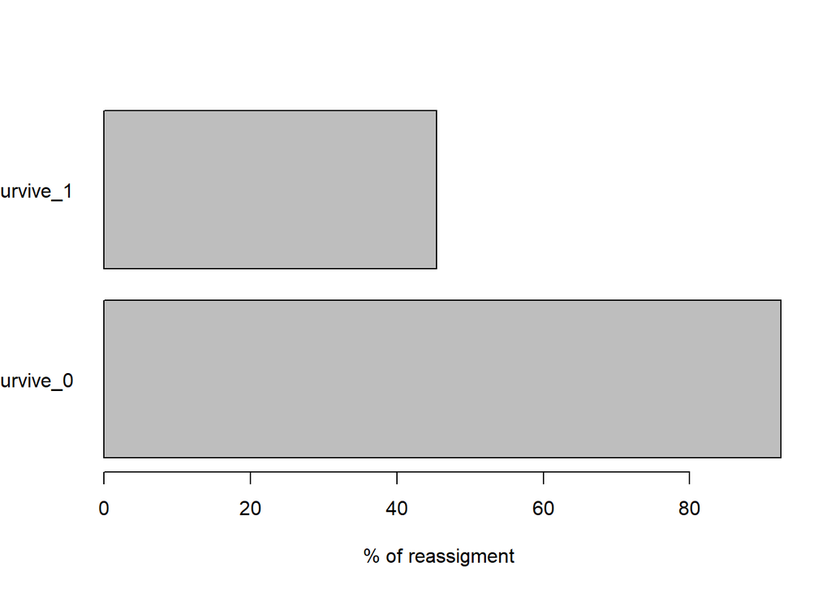

```r
temporiginal <- summary(dapc(vcf_chambers,pop(vcf_chambers), n.pca = 25, n.da = 3))$assign.per.pop*100


temp <- summary(dapc(vcf_chambers, n.pca = 25, n.da = 3))$assign.per.pop*100

barplot(temporiginal, xlab = "% of reassigment", horiz = TRUE, las=1)
```

```r
barplot(temp, xlab = "% of reassigment", horiz = TRUE, las=1)
```

[output not shown]

# 9.- ¿Qué esperamos ver si el modelo no está over-fit?

Que al aleatorizarse los datos no se vea una diferencia entre grupos tan definida.

# 10.- ¿Qué hace temp$tab? y porqué del 1 al 5?

dapc2 <- dapc(microbov, n.da=100, n.pca=50) temp <- a.score(dapc2) names(temp)

Visibiliza la tabla de datos de cada simulacion para cada poblacion.

```r
dapc2 <- dapc(microbov, n.da=100, n.pca=50)
temp <- a.score(dapc2)
names(temp)
```

```
## [1] "tab"       "pop.score" "mean"
```

```r
temp$tab
```

```
##        Borgou Zebu Lagunaire     NDama Somba Aubrac  Bazadais BlondeAquitaine
## sim.1    0.66 0.54 0.8431373 0.8000000  0.72   0.58 0.8085106       0.5081967
## sim.2    0.58 0.62 0.7647059 0.8333333  0.66   0.68 0.7234043       0.5245902
## sim.3    0.58 0.64 0.6078431 0.6666667  0.66   0.60 0.5319149       0.4098361
## sim.4    0.52 0.78 0.7647059 0.8333333  0.68   0.56 0.6170213       0.5081967
## sim.5    0.64 0.68 0.7058824 0.7000000  0.78   0.50 0.7446809       0.6065574
## sim.6    0.52 0.80 0.6862745 0.8333333  0.78   0.68 0.7872340       0.3606557
## sim.7    0.64 0.74 0.6274510 0.5666667  0.74   0.66 0.6595745       0.6229508
## sim.8    0.62 0.80 0.7450980 0.7333333  0.68   0.58 0.5531915       0.5573770
## sim.9    0.62 0.62 0.8235294 0.7666667  0.70   0.52 0.8297872       0.4918033
## sim.10   0.62 0.48 0.7647059 0.7666667  0.68   0.68 0.7234043       0.5573770
##        BretPieNoire Charolais Gascon Limousin MaineAnjou Montbeliard Salers
## sim.1     0.5483871 0.6181818   0.64     0.60  0.6938776   0.6000000   0.62
## sim.2     0.5806452 0.6363636   0.62     0.70  0.6734694   0.7000000   0.70
## sim.3     0.7096774 0.6181818   0.60     0.74  0.7142857   0.7666667   0.66
## sim.4     0.3548387 0.6909091   0.58     0.40  0.7959184   0.6666667   0.70
## sim.5     0.5806452 0.6727273   0.74     0.58  0.7142857   0.7333333   0.48
## sim.6     0.5483871 0.6000000   0.56     0.58  0.4897959   0.7333333   0.62
## sim.7     0.6129032 0.7272727   0.78     0.56  0.7346939   0.6000000   0.68
## sim.8     0.4838710 0.5454545   0.54     0.62  0.7959184   0.5333333   0.58
## sim.9     0.4838710 0.6363636   0.60     0.60  0.6734694   0.7000000   0.62
## sim.10    0.4838710 0.6000000   0.64     0.58  0.7142857   0.7000000   0.50
```

```r
temp$tab[1:5,1:5]
```

```
##       Borgou Zebu Lagunaire     NDama Somba
## sim.1   0.66 0.54 0.8431373 0.8000000  0.72
## sim.2   0.58 0.62 0.7647059 0.8333333  0.66
## sim.3   0.58 0.64 0.6078431 0.6666667  0.66
## sim.4   0.52 0.78 0.7647059 0.8333333  0.68
## sim.5   0.64 0.68 0.7058824 0.7000000  0.78
```

# 11.- ¿Qué significa sim.1, sim.2?

```r
temp$tab[1:5,1:5]
```

```
##       Borgou Zebu Lagunaire     NDama Somba
## sim.1   0.66 0.54 0.8431373 0.8000000  0.72
## sim.2   0.58 0.62 0.7647059 0.8333333  0.66
## sim.3   0.58 0.64 0.6078431 0.6666667  0.66
## sim.4   0.52 0.78 0.7647059 0.8333333  0.68
## sim.5   0.64 0.68 0.7058824 0.7000000  0.78
```

# 12.- ¿De qué sirve saber la media del score?

Para tener un parametro a partir del cual comparar el promedio de cada poblacion. Se puede identificar qué poblaciones están por encima o por debajo de la media general y detectar valores extremos.

```r
temp$pop.score
```

```
##          Borgou            Zebu       Lagunaire           NDama           Somba
##       0.6000000       0.6700000       0.7333333       0.7500000       0.7080000
##          Aubrac        Bazadais BlondeAquitaine    BretPieNoire       Charolais
##       0.6040000       0.6978723       0.5147541       0.5387097       0.6345455
##          Gascon        Limousin      MaineAnjou     Montbeliard          Salers
##       0.6300000       0.5960000       0.7000000       0.6733333       0.6160000
```

```r
temp$mean
```

```
## [1] 0.6444365
```

# 13.- ¿Qué habría que hacer distinto?

Calcule a-score del dapc generado con find.cluster y del dapc generado con los grupos asintomatico y sintomatico. En realidad solo tendría que hacer la optimización a partir del dapc con los grupos definidos asintomaticos y sintomaticos.

```r
grp <- find.clusters(vcf_chambers, max.n.clust = 20, n.pca = 70, choose = FALSE, stat = "BIC", method = "kmeans")

# corremos dapc con los grupos formados
dapcfindcluster <- dapc(vcf_chambers, grp$grp, n.pca = 20, n.da = 70)

temp <- optim.a.score(dapcfindcluster)
```

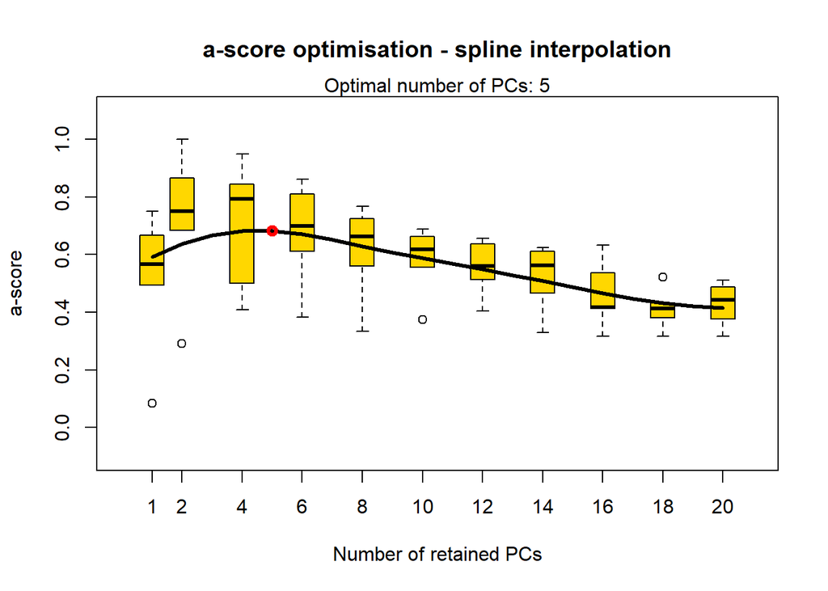

# 14.- ¿Qué hace NA.method=”mean” y por qué se ocupa?

Remplaza los valores NA por el promedio de los valores que no tienen NA y corresponden a los sitios variantes. Se ocupa porque para construir una matriz no podemos tener NA

```r
data(nancycats)
x <- nancycats
nancycats@pop
```

```
##   [1] P01 P01 P01 P01 P01 P01 P01 P01 P01 P01 P02 P02 P02 P02 P02 P02 P02 P02
##  [19] P02 P02 P02 P02 P02 P02 P02 P02 P02 P02 P02 P02 P02 P02 P03 P03 P03 P03
##  [37] P03 P03 P03 P03 P03 P03 P03 P03 P04 P04 P04 P04 P04 P04 P04 P04 P04 P04
##  [55] P04 P04 P04 P04 P04 P04 P04 P04 P04 P04 P04 P04 P04 P05 P05 P05 P05 P05
##  [73] P05 P05 P05 P05 P05 P05 P05 P05 P05 P05 P06 P06 P06 P06 P06 P06 P06 P06
##  [91] P06 P06 P06 P07 P07 P07 P07 P07 P07 P07 P07 P07 P07 P07 P07 P07 P07 P08
## [109] P08 P08 P08 P08 P08 P08 P08 P08 P08 P09 P09 P09 P09 P09 P09 P09 P09 P09
## [127] P10 P10 P10 P10 P10 P10 P10 P10 P10 P10 P10 P11 P11 P11 P11 P11 P11 P11
## [145] P11 P11 P11 P11 P11 P11 P11 P11 P11 P11 P11 P11 P11 P12 P12 P12 P12 P12
## [163] P12 P12 P13 P13 P13 P13 P13 P13 P13 P13 P13 P13 P13 P13 P13 P14 P14 P14
## [181] P14 P14 P14 P14 P14 P14 P14 P14 P14 P14 P14 P14 P14 P14 P15 P15 P15 P15
## [199] P15 P15 P15 P15 P15 P15 P15 P16 P16 P16 P16 P16 P16 P16 P16 P16 P16 P16
## [217] P16 P12 P12 P12 P12 P12 P12 P12 P17 P17 P17 P17 P17 P17 P17 P17 P17 P17
## [235] P17 P17 P17
## 17 Levels: P01 P02 P03 P04 P05 P06 P07 P08 P09 P10 P11 P12 P13 P14 P15 ... P17
```

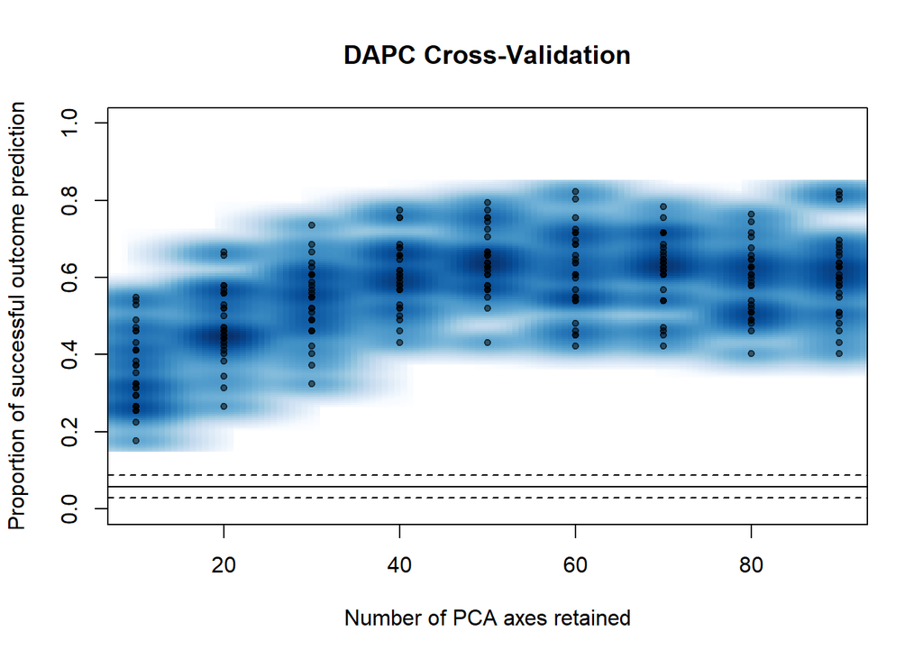

```r
mat <- tab(x, NA.method="mean")
grp <- pop(x)
xval <- xvalDapc(mat, grp, n.pca.max = 300, training.set = 0.9,
result = "groupMean", center = TRUE, scale = FALSE,
n.pca = NULL, n.rep = 30, xval.plot = TRUE)
```

```r
xval
```

```
## $`Cross-Validation Results`
##     n.pca   success
## 1      10 0.2549020
## 2      10 0.4117647
## 3      10 0.3235294
## 4      10 0.3725490
## 5      10 0.4313725
## 6      10 0.3235294
## 7      10 0.2647059
## 8      10 0.5294118
## 9      10 0.2941176
## 10     10 0.4607843
## 11     10 0.5490196
## 12     10 0.3823529
## 13     10 0.3235294
```

[output cut: 312 more lines]

# 15.- Datos camaras

## a) Encontrar cluster de la estructura de los datos

```r
#Crear objeto genlight con datos camaras
vcfR_chambers <- read.vcfR("../../../../VCF/GBSM_Fenotype_AECCCA.recode.vcf")
```

[output not shown]

```r
vcf_chambers<-vcfR2genlight(vcfR_chambers)

# corremos find.cluster, se escoje un numero maximo de clusters
grp <- find.clusters(vcf_chambers, max.n.clust = 20, n.pca = 50, choose = FALSE, stat = "BIC", method = "kmeans")

table(grp$grp)
```

```
##
##  1  2  3  4
## 11 15 16 14
```

```r
grp$grp
```

```
## AE01_N04TAF AE02_N04TAF AE05_N04TAF AE06_N04TAF AE08_N04TAF AE10_N04TAF
##           1           4           3           2           3           2
## AE12_N04TAF AE13_N04TAF AE14_N04TAF AE15_N04TAF AE16_N04TAF AE18_N04TAF
##           1           4           3           4           2           4
## AE19_N04TAF AE23_N04TAF AE24_N04TAF AE25_N04TAF AE28_N04TAF AE29_N04TAF
##           4           2           1           4           3           3
## CA03_N04TAF CA04_N04TAF CA06_N04TAF CA07_N04TAF CA09_N04TAF CA10_N04TAF
##           3           3           4           3           4           2
## CA11_N04TAF CA14_N04TAF CA16_N04TAF CA17_N04TAF CA18_N04TAF CA19_N04TAF
##           4           3           3           3           2           1
## CA21_N04TAF CA22_N04TAF CA25_N04TAF CA27_N04TAF CA28_N04TAF CA29_N04TAF
##           2           2           2           4           1           1
## CA30_N04TAF CC01_N04TAF CC02_N04TAF CC03_N04TAF CC07_N04TAF CC09_N04TAF
##           4           2           2           2           2           3
## CC10_N04TAF CC11_N04TAF CC13_N04TAF CC15_N04TAF CC16_N04TAF CC17_N04TAF
##           2           4           4           1           1           3
## CC20_N04TAF CC21_N04TAF CC23_N04TAF CC24_N04TAF CC26_N04TAF CC27_N04TAF
##           1           3           1           2           4           3
## CC29_N04TAF CC30_N04TAF
##           3           1
## Levels: 1 2 3 4
```

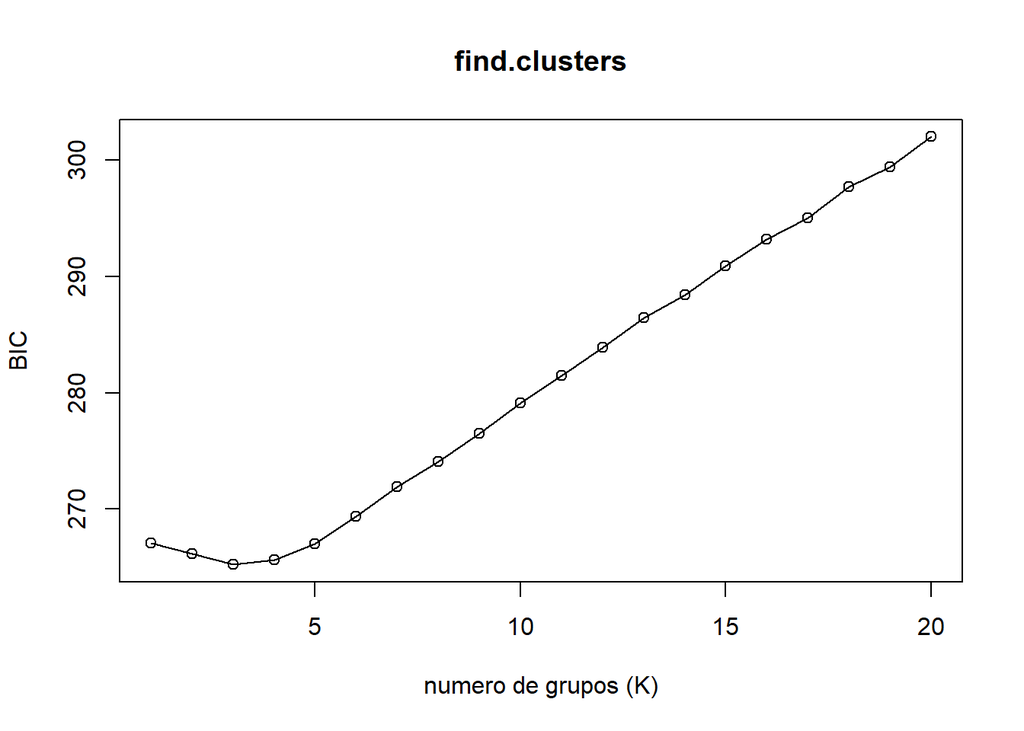

```r
##

plot(grp$Kstat, type = "o", xlab = "numero de grupos (K)",
     ylab = "BIC",
     main = "find.clusters")
```

```r
# corremos dapc con los grupos formados
dapc1 <- dapc(vcf_chambers, grp$grp, n.pca = 50, n.da = 3)

dapc1
```

```
##  #################################################
##  # Discriminant Analysis of Principal Components #
##  #################################################
## class: dapc
## $call: dapc.genlight(x = vcf_chambers, pop = grp$grp, n.pca = 50, n.da = 3)
##
## $n.pca: 50 first PCs of PCA used
## $n.da: 3 discriminant functions saved
## $var (proportion of conserved variance): 0.956
##
## $eig (eigenvalues): 71060 33530 13650  vector    length content
## 1 $eig      3      eigenvalues
## 2 $grp      56     prior group assignment
## 3 $prior    4      prior group probabilities
## 4 $assign   56     posterior group assignment
## 5 $pca.cent 2080   centring vector of PCA
## 6 $pca.norm 2080   scaling vector of PCA
## 7 $pca.eig  55     eigenvalues of PCA
##
##   data.frame    nrow ncol content
## 1 $tab          56   50   retained PCs of PCA
## 2 $means        4    50   group means
## 3 $loadings     50   3    loadings of variables
## 4 $ind.coord    56   3    coordinates of individuals (principal components)
## 5 $grp.coord    4    3    coordinates of groups
## 6 $posterior    56   4    posterior membership probabilities
## 7 $pca.loadings 2080 50   PCA loadings of original variables
## 8 $var.contr    2080 3    contribution of original variables
```

```r
myCol <- c("purple","green","orange","red","blue")

scatter(dapc1, scree.da=T, bg="white",scree.pca=TRUE, pch=20, cell=0, cstar=0, col=myCol, solid=.4,
cex=3,clab=0, leg=TRUE, txt.leg=paste("Cluster",1:5))
```

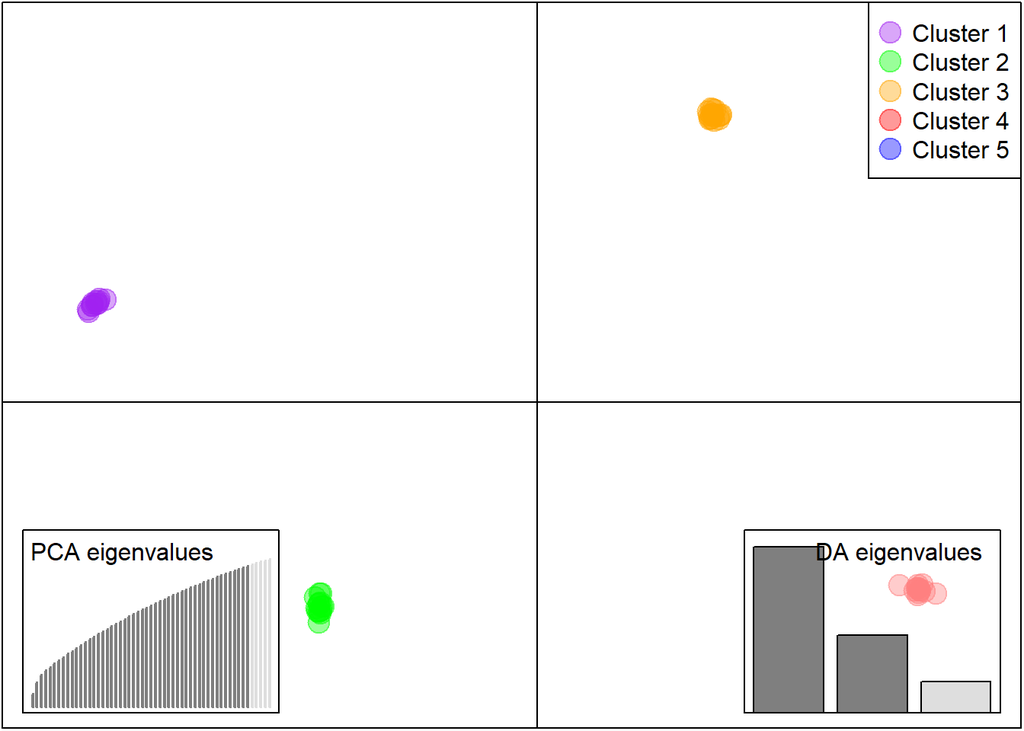

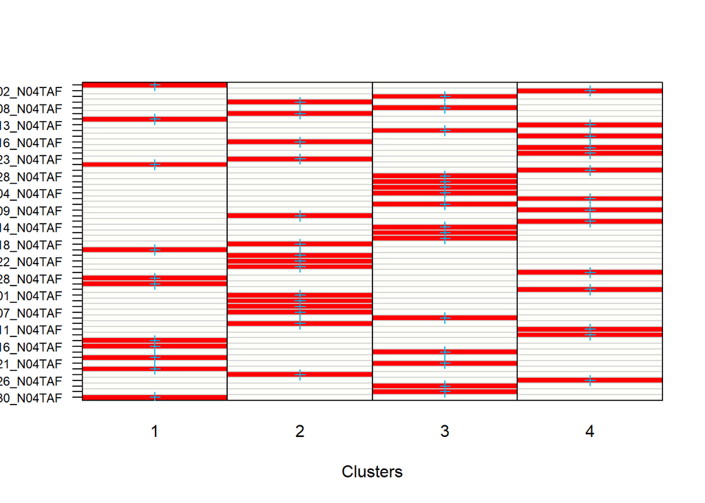

```r
assignplot(dapc1)
```

## b) Generar DAPC con los grupos definidos para asintomaticos y sintomaticos

```r
meta <- read.table("../outputs/pop_Fenotype_AECCCA_DAPC.txt", header=TRUE, sep="\t")  # Si está separado por tabulaciones

pop(vcf_chambers) <- meta$suv_damozo

dapc1chamberAECCCA <- dapc(vcf_chambers, n.pca = 50, n.da = 3)
# cargamos los datos de las categorias de daño

vcf_chambers@pop
```

```
##  [1] survive_1 survive_1 survive_0 survive_1 survive_0 survive_0 survive_0
##  [8] survive_0 survive_0 survive_0 survive_0 survive_0 survive_0 survive_0
## [15] survive_1 survive_0 survive_0 survive_0 survive_1 survive_1 survive_1
## [22] survive_1 survive_1 survive_1 survive_1 survive_0 survive_0 survive_0
## [29] survive_1 survive_0 survive_0 survive_0 survive_0 survive_0 survive_0
## [36] survive_0 survive_1 survive_0 survive_0 survive_0 survive_0 survive_0
## [43] survive_1 survive_1 survive_0 survive_1 survive_1 survive_1 survive_1
## [50] survive_0 survive_0 survive_0 survive_1 survive_0 survive_1 survive_0
## Levels: survive_0 survive_1
```

```r
dapc1chamberAECCCA
```

```
##  #################################################
##  # Discriminant Analysis of Principal Components #
##  #################################################
## class: dapc
## $call: dapc.genlight(x = vcf_chambers, n.pca = 50, n.da = 3)
##
## $n.pca: 50 first PCs of PCA used
## $n.da: 1 discriminant functions saved
## $var (proportion of conserved variance): 0.956
##
## $eig (eigenvalues): 441.6  vector    length content
## 1 $eig      1      eigenvalues
## 2 $grp      56     prior group assignment
## 3 $prior    2      prior group probabilities
## 4 $assign   56     posterior group assignment
## 5 $pca.cent 2080   centring vector of PCA
## 6 $pca.norm 2080   scaling vector of PCA
## 7 $pca.eig  55     eigenvalues of PCA
##
##   data.frame    nrow ncol content
## 1 $tab          56   50   retained PCs of PCA
## 2 $means        2    50   group means
## 3 $loadings     50   1    loadings of variables
## 4 $ind.coord    56   1    coordinates of individuals (principal components)
## 5 $grp.coord    2    1    coordinates of groups
## 6 $posterior    56   2    posterior membership probabilities
## 7 $pca.loadings 2080 50   PCA loadings of original variables
## 8 $var.contr    2080 1    contribution of original variables
```

## c) Generar resumen

```r
summary(dapc1chamberAECCCA)
```

```
## $n.dim
## [1] 1
##
## $n.pop
## [1] 2
##
## $assign.prop
## [1] 0.9642857
##
## $assign.per.pop
## survive_0 survive_1
## 0.9714286 0.9523810
##
## $prior.grp.size
##
## survive_0 survive_1
##        35        21
##
## $post.grp.size
##
## survive_0 survive_1
##        35        21
```

## d) plot

```r
scatter(dapc1chamberAECCCA, scree.da=T, bg="white",scree.pca=TRUE, pch=20, cell=0, cstar=0, col=myCol, solid=.4,
cex=3,clab=0, leg=TRUE, txt.leg=paste("Cluster",1:2))
```

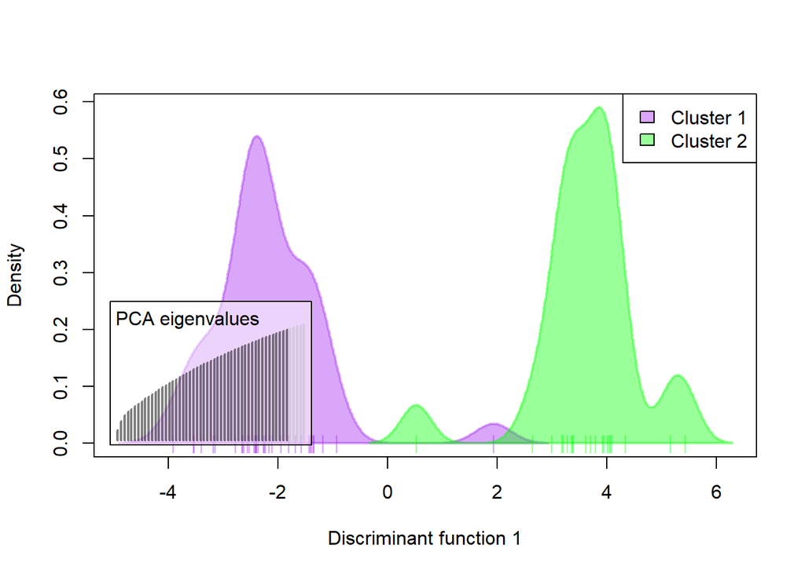

## d) asignacion

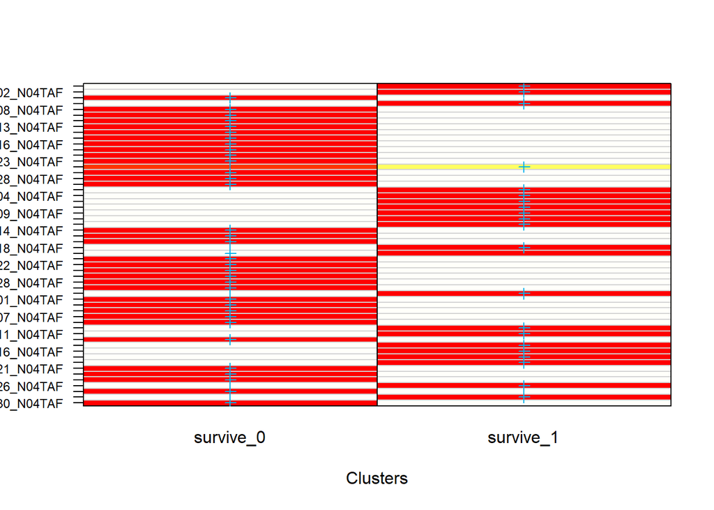

```r
assignplot(dapc1chamberAECCCA)
```

```r
temp <- summary(dapc1chamberAECCCA)$assign.per.pop*100
temp
```

```
## survive_0 survive_1
##  97.14286  95.23810
```

```r
temp <- a.score(dapc1chamberAECCCA)
temp
```

```
## $tab
##          survive_0   survive_1
## sim.1  -0.02857143 -0.04761905
## sim.2  -0.02857143 -0.04761905
## sim.3  -0.02857143 -0.04761905
## sim.4  -0.02857143 -0.04761905
## sim.5   0.00000000  0.00000000
## sim.6  -0.02857143  0.00000000
## sim.7   0.00000000  0.00000000
## sim.8  -0.02857143  0.00000000
## sim.9  -0.02857143 -0.04761905
## sim.10  0.00000000  0.00000000
##
## $pop.score
##   survive_0   survive_1
## -0.02000000 -0.02380952
##
## $mean
## [1] -0.02190476
```